# Fortune - Most Powerful Women 2018

Anna Vasylytsya

October 10, 2018

### Introduction

> “The Most Powerful Women in Business list is compiled by Fortune editors, who consider four criteria: the size and importance of the woman’s business in the global economy, the health and direction of the business, the arc of the woman’s career (résumé and runway ahead), and social and cultural influence.” [Source](http://fortune.com/2018/09/24/fortune-most-powerful-women-methodology-2018/)

The data that was available on Fortunte’s website only on partly captures the first two criteria (which are more quantiative) and do not capture the latter two factors at all (which are more subjective).

Since I have taken the trouble of scraping this data, I explore the data below.

```r
library(rio)
women <- import("https://raw.githubusercontent.com/annnvv/most_powerful_women_2018/master/data/fortune_most_powerful_women_2018.csv", header = TRUE)

library(DT)
datatable(women[ , c(1:8, 12)], rownames = FALSE)
```

| rank | name | age | title | affiliation | revenue | profit | market_value | links |
| --- | --- | --- | --- | --- | --- | --- | --- | --- |
| 1 | Marillyn Hewson | 64 | Chairman President and CEO | Lockheed Martin | 51048 | 2002 | 97199.9 | http://fortune.com/most-powerful-women/marillyn-hewson-1/ |
| 2 | Mary Barra | 56 | Chairman and CEO | General Motors | 157311 | -3864 | 49522.2 | http://fortune.com/most-powerful-women/mary-barra-2/ |
| 3 | Abigail Johnson | 56 | Chairman and CEO | Fidelity Investments |  |  |  | http://fortune.com/most-powerful-women/abigail-johnson-3/ |
| 4 | Ginni Rometty | 61 | Chairman President and CEO | IBM | 79139 | 5753 | 135600.8 | http://fortune.com/most-powerful-women/ginni-rometty-4/ |
| 5 | Gail Boudreaux | 58 | President and CEO | Anthem | 90039.4 | 3842.8 | 70439.6 | http://fortune.com/most-powerful-women/gail-boudreaux-5/ |
| 6 | Sheryl Sandberg | 49 | COO | Facebook | 40653 | 15934 | 462821.2 | http://fortune.com/most-powerful-women/sheryl-sandberg-6/ |
| 7 | Safra Catz | 56 | Co-CEO | Oracle | 39831 | 3825 | 195196 | http://fortune.com/most-powerful-women/safra-catz-7/ |
| 8 | Phebe Novakovic | 60 | Chairman and CEO | General Dynamics | 30973 | 2912 | 60622.1 | http://fortune.com/most-powerful-women/phebe-novakovic-8/ |
| 9 | Ruth Porat | 60 | SVP and CFO | Google Alphabet | 110855 | 12662 | 809871.7 | http://fortune.com/most-powerful-women/ruth-porat-9/ |
| 10 | Susan Wojcicki | 50 | CEO | YouTube Google Alphabet | 110855 | 12662 | 809871.7 | http://fortune.com/most-powerful-women/susan-wojcicki-10/ |

[output cut: 41 more lines]

### Averages

Of the women on the list, 62.7 percent are CEOs, 45.1 percent are presidents, and 23.5 percent are chairmen. Note: these figures are not mutually exclusive.

### Market Value by Rank

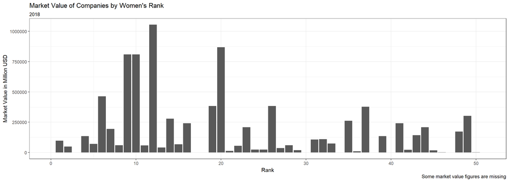

```r
library(ggplot2)
ggplot(women, aes(x = rank, y = market_value)) +
  geom_bar(stat = "identity") +
  theme_bw() +
  labs(title = "Market Value of Companies by Women's Rank", subtitle = "2018",
       caption = "Some market value figures are missing",
       x = "Rank", y = "Market Value in Million USD") +
  scale_x_continuous(limits = c(0, 51), minor_breaks = 5)
```

## Age Distribution

The average age of women on Fortune’s list is 55.4 years old. The youngest person on this list is 46 years old.

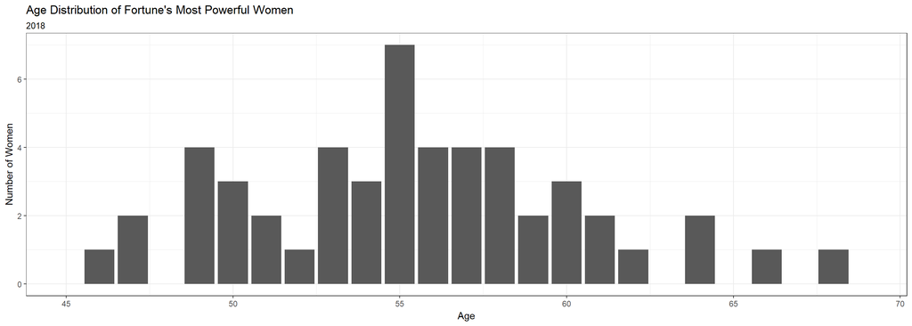

```r
library(ggplot2)
ggplot(data = women, aes(women$age)) +
  geom_bar() +
  theme_bw() +
  labs(title = "Age Distribution of Fortune's Most Powerful Women", subtitle = "2018",
     x = "Age", y = "Number of Women") +
  scale_x_continuous(limits = c(45, 69)) +
  scale_y_continuous(limits = c(0, 7))
```

## Age and Rank

This scatter plot and the histogram above indicate that women on this list tends to be between 50-65 years old.

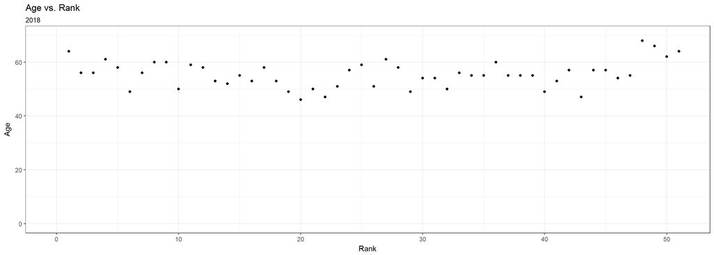

```r
library(ggplot2)
ggplot(data = women, aes(x = women$rank, y = women$age)) +
  geom_point() +
  theme_bw() +
  labs(title = "Age vs. Rank", subtitle = "2018",
     x = "Rank", y = "Age") +
  scale_x_continuous(limits = c(0, 51)) +
  scale_y_continuous(limits = c(0, 70))
```

#### Thoughts on extending the analysis

One additional variable that would be interesting to add to this dataset is the sector that these women work in. Also, it would be interesting to know how many of these women are married and how many have children.